# 16.3: Smart Drug (two groups)

## Introduction

This is the example from Section 16.3 of Kruschke on the (fictitious) effect of the “smart drug”, this time comparing the “smart drug” group against the placebo group. Make sure the “TwoGroupIQ.csv” file is in your project directory.

## Preliminaries

Load necessary packages:

```r
library(tidyverse)
library(rstan)
library(shinystan)
library(bayesplot)
```

Set Stan to save compiled code.

```r
rstan_options(auto_write = TRUE)
```

Set Stan to use parallel processing where possible.

```r
options(mc.cores = parallel::detectCores())
```

## Data

```r
IQ_data <- read_csv("TwoGroupIQ.csv")
IQ_data
```

| Score | Group |
| --- | --- |
| 102 | Smart Drug |
| 107 | Smart Drug |
| 92 | Smart Drug |
| 101 | Smart Drug |
| 110 | Smart Drug |
| 68 | Smart Drug |
| 119 | Smart Drug |
| 106 | Smart Drug |
| 99 | Smart Drug |
| 103 | Smart Drug |

[output cut: 110 more lines]

Since we are now comparing both groups, we can use the whole data set (120 total observations: 63 experimental and 57 control):

```r
table(IQ_data$Group)
```

```
   Placebo Smart Drug
        57         63
```

We will, however, need to give the groups numerical values to pass to Stan (rather than the strings “Smart Drug” and “Placebo”). The easiest way to do this is to `factor` the `Group` variable. This will change the underlying structure to 1s and 2s. Observe:

```r
x <- factor(IQ_data$Group,
            levels = c("Smart Drug", "Placebo"))
str(x)
```

```
 Factor w/ 2 levels "Smart Drug","Placebo": 1 1 1 1 1 1 1 1 1 1 ...
```

Now “Smart Drug” is 1 and “Placebo” is 2. All we have to do is convert this factor variable into a vector of integers that Stan will accept.

```r
x <- as.integer(x)
```

And bundle everything together into a list:

```r
N <- NROW(IQ_data)
y <- IQ_data$Score
stan_data <- list(N = N, x = x, y = y)
```

## Stan code

Now we include the `x` variable that is either 1 or 2 to indicate group. We also let `mu` and `sigma` have two possible values.

The only change to the model is the likelihood:

```
y ~ student_t(nu, mu[x], sigma[x]);
```

The terms `mu[x]` and `sigma[x]` ensure that the `y` value is used only for the group to which that observation belongs (1 or 2).

One more interesting change is to the `generated quantities` block. We’ve only used this to generate random draws from our posterior for posterior predictive checks. But technically, we can calculate anything we want in this block. Since the difference of two means is the primary object of our inference, we compute a `diff` variable here as the difference in the two sampled values of `mu`.

```stan
data {
    int<lower = 0> N;
    int<lower = 1, upper = 2> x[N];
    real<lower = 0> y[N];
}
transformed data {
    real<lower = 0> Rate;
    real<lower = 0> M;
    real<lower = 0> S;
    real<lower = 0> L;
    real<lower = 0> H;

    Rate = 1.0/29.0;
    M = 100;
    S = 100;
    L = 0;
    H = 1000;
}
parameters {
    real<lower = 0> nu_minus_one;
    real<lower = 0> mu[2];
    real<lower = 0> sigma[2];
}
transformed parameters {
    real<lower = 0> nu;

    nu = nu_minus_one + 1;
}
model {
    nu_minus_one ~ exponential(Rate);
    mu ~ normal(M, S);
    sigma ~ uniform(L, H);
    y ~ student_t(nu, mu[x], sigma[x]);
}
generated quantities {
    real y_rep[N];
    real diff;

    for (n in 1:N) {
        y_rep[n] = student_t_rng(nu, mu[x[n]], sigma[x[n]]);
    }

    diff = mu[1] - mu[2];
}
```

## Sampling from the model

```r
set.seed(11111)
fit_IQ2 <- sampling(IQ2, data = stan_data, refresh = 0)
```

## Diagnosing the model

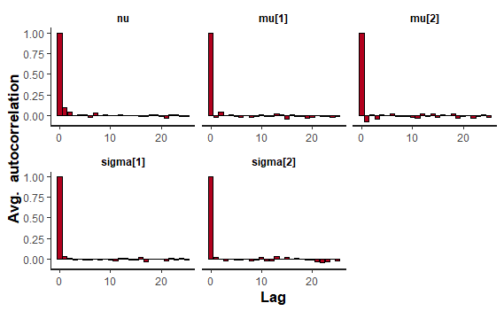

```r
plot(fit_IQ2, plotfun = "ac", pars = c("nu", "mu", "sigma"))
```

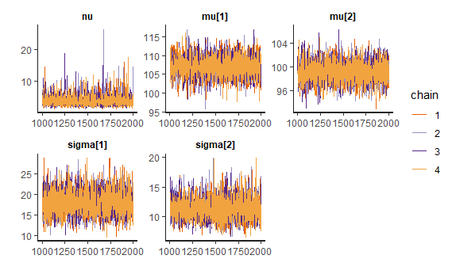

```r
plot(fit_IQ2, plotfun = "trace",
     pars = c("nu", "mu", "sigma"))
```

## Summarizing the model

```r
print(fit_IQ2, pars = c("nu", "mu", "sigma", "diff"))
```

```
Inference for Stan model: stan-4341ef32e29.
4 chains, each with iter=2000; warmup=1000; thin=1;
post-warmup draws per chain=1000, total post-warmup draws=4000.

           mean se_mean   sd   2.5%    25%    50%    75%  97.5%
nu         3.85    0.03 1.65   1.91   2.80   3.51   4.48   7.97
mu[1]    107.12    0.04 2.64 101.94 105.37 107.11 108.83 112.21
mu[2]     99.28    0.03 1.75  95.86  98.10  99.28 100.45 102.74
sigma[1]  17.89    0.05 2.79  12.89  15.96  17.70  19.68  23.69
sigma[2]  11.33    0.03 1.76   8.26  10.14  11.20  12.40  15.14
diff       7.84    0.05 3.21   1.67   5.62   7.89  10.03  13.96
         n_eff Rhat
nu        2744    1
mu[1]     3767    1
mu[2]     4659    1
sigma[1]  3666    1
sigma[2]  3827    1
diff      3862    1

Samples were drawn using NUTS(diag_e) at Wed May 29 23:48:58 2019.
For each parameter, n_eff is a crude measure of effective sample size,
and Rhat is the potential scale reduction factor on split chains (at
convergence, Rhat=1).
```

## Visualizing the model

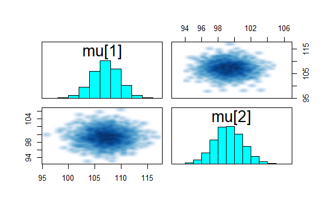

```r
pairs(fit_IQ2, pars = c("mu"))
```

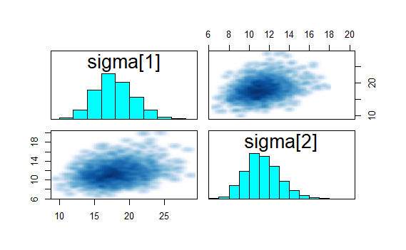

```r
pairs(fit_IQ2, pars = c("sigma"))
```

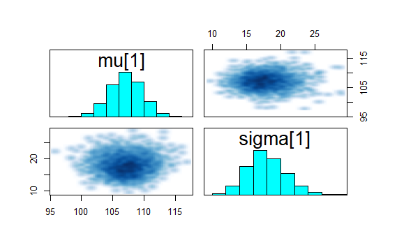

```r
pairs(fit_IQ2, pars = c("mu[1]", "sigma[1]"))
```

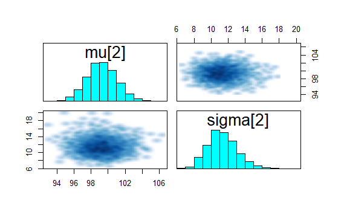

```r
pairs(fit_IQ2, pars = c("mu[2]", "sigma[2]"))
```

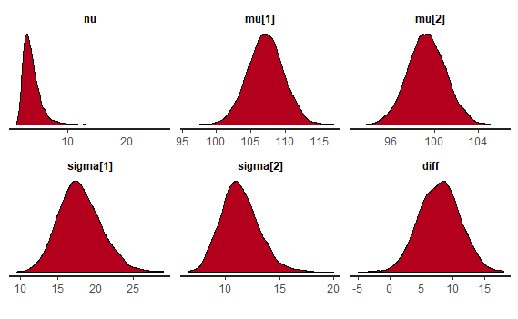

```r
plot(fit_IQ2, plotfun = "dens", pars = c("nu", "mu", "sigma", "diff"))
```

```
ci_level: 0.8 (80% intervals)
outer_level: 0.95 (95% intervals)
```

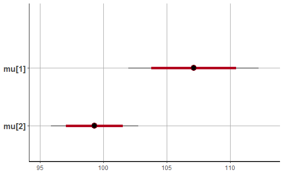

```r
plot(fit_IQ2, pars = c("mu"))
```

```
ci_level: 0.8 (80% intervals)
outer_level: 0.95 (95% intervals)
```

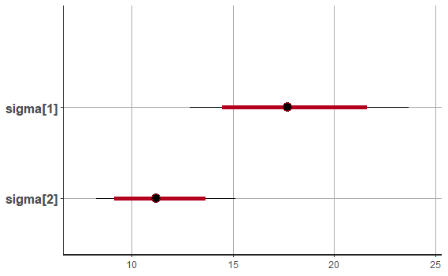

```r
plot(fit_IQ2, pars = c("sigma"))
```

```
ci_level: 0.8 (80% intervals)
outer_level: 0.95 (95% intervals)
```

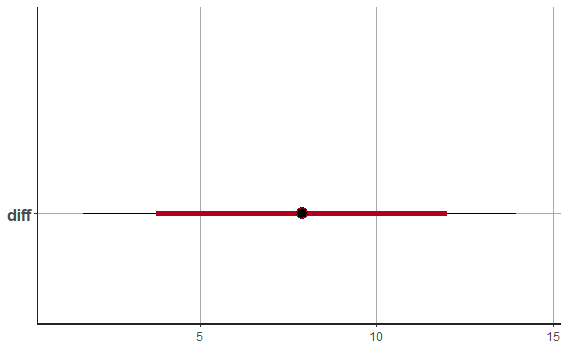

```r
plot(fit_IQ2, pars = c("diff"))
```

## Examining the prior

```stan
data {
    int<lower = 0> N;
    int<lower = 1, upper = 2> x[N];
    real<lower = 0> y[N];
}
transformed data {
    real<lower = 0> Rate;
    real<lower = 0> M;
    real<lower = 0> S;
    real<lower = 0> L;
    real<lower = 0> H;

    Rate = 1.0/29.0;
    M = 100;
    S = 100;
    L = 0;
    H = 1000;
}
parameters {
    real<lower = 0> nu_minus_one;
    real<lower = 0> mu[2];
    real<lower = 0> sigma[2];
}
transformed parameters {
    real<lower = 0> nu;

    nu = nu_minus_one + 1;
}
model {
    nu_minus_one ~ exponential(Rate);
    mu ~ normal(M, S);
    sigma ~ uniform(L, H);
//    y ~ student_t(nu, mu[x], sigma[x]);
}
```

```r
set.seed(11111)
fit_IQ2_prior <- sampling(IQ2_prior, data = stan_data, refresh = 0)
```

```
There were 3735 divergent transitions after warmup. Increasing adapt_delta above 0.8 may help. See
http://mc-stan.org/misc/warnings.html#divergent-transitions-after-warmupExamine the pairs() plot to diagnose sampling problems
```

```r
fit_IQ2_prior
```

```
Inference for Stan model: stan-43462cf7cd7.
4 chains, each with iter=2000; warmup=1000; thin=1;
post-warmup draws per chain=1000, total post-warmup draws=4000.

               mean se_mean     sd  2.5%    25%    50%    75%
nu_minus_one  31.72    1.49  30.44  0.65  10.52  23.75  43.12
mu[1]        127.92    5.98  79.53  9.97  60.63 118.57 182.52
mu[2]        134.76    4.83  79.18 14.46  71.76 125.42 186.19
sigma[1]     507.96   19.02 286.04 25.18 258.01 525.32 755.02
sigma[2]     523.93   25.00 286.87 19.15 287.14 526.79 776.84
nu            32.72    1.49  30.44  1.65  11.52  24.75  44.12
lp__          22.23    0.19   2.06 17.04  21.08  22.59  23.73
              97.5% n_eff Rhat
nu_minus_one 114.89   418 1.01
mu[1]        294.47   177 1.03
mu[2]        310.27   269 1.03
sigma[1]     964.18   226 1.02
sigma[2]     981.78   132 1.02
nu           115.89   418 1.01
lp__          25.17   121 1.02

Samples were drawn using NUTS(diag_e) at Wed May 29 23:50:31 2019.
For each parameter, n_eff is a crude measure of effective sample size,
and Rhat is the potential scale reduction factor on split chains (at
convergence, Rhat=1).
```

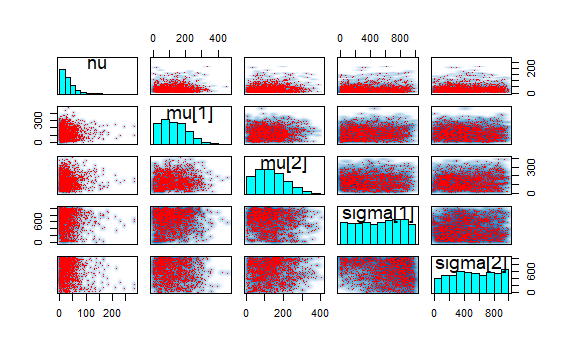

```r
pairs(fit_IQ2_prior, pars = c("nu", "mu", "sigma"))
```

```
ci_level: 0.8 (80% intervals)
outer_level: 0.95 (95% intervals)
```

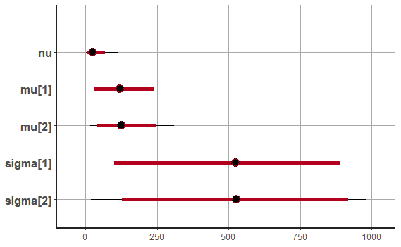

```r
plot(fit_IQ2_prior, pars = c("nu", "mu", "sigma"))
```

## Posterior predictive check

Extract predicted values:

```r
samples_IQ2 <- extract(fit_IQ2)
y_rep <- samples_IQ2$y_rep
```

There are interesting posterior predictive checks for grouped data.

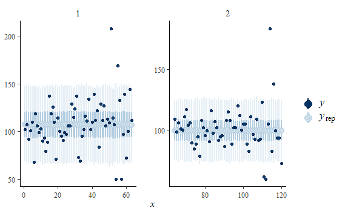

```r
ppc_intervals_grouped(y, y_rep, group = x)
```

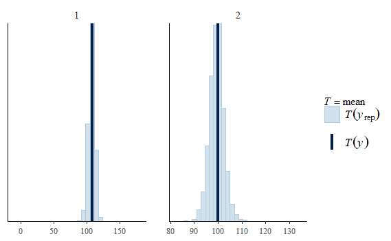

```r
ppc_stat_grouped(y, y_rep, group = x)
```

Or we can use the familiar ones as long as we’re careful to subset. We’ll make a vector of which y values belong to which group:

```r
drug <- which(x == 1)
placebo <- which(x == 2)
```

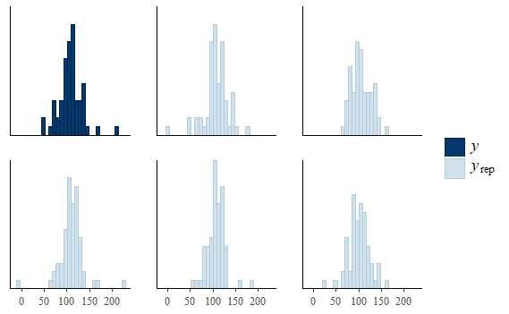

```r
ppc_hist(y[drug], y_rep[1:5, drug])
```

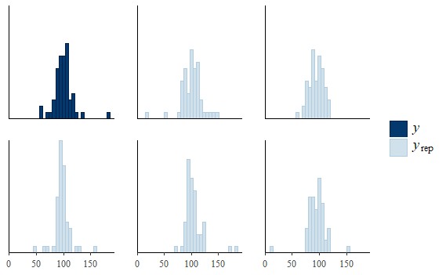

```r
ppc_hist(y[placebo], y_rep[1:5, placebo])
```

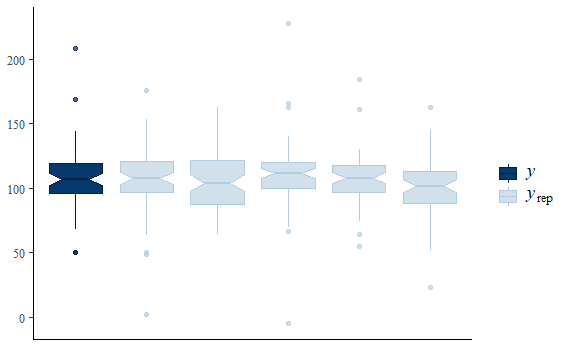

```r
ppc_boxplot(y[drug], y_rep[1:5, drug])
```

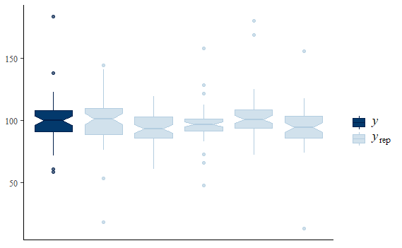

```r
ppc_boxplot(y[placebo], y_rep[1:5, placebo])
```

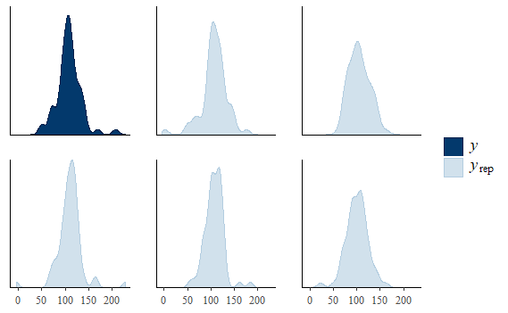

```r
ppc_dens(y[drug], y_rep[1:5, drug])
```

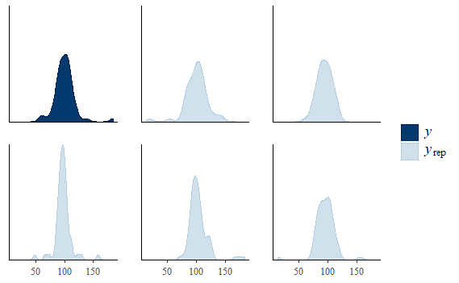

```r
ppc_dens(y[placebo], y_rep[1:5, placebo])
```

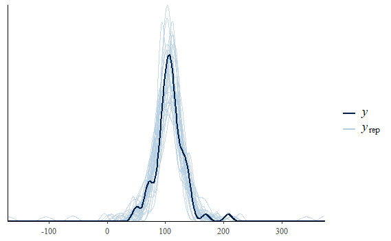

```r
ppc_dens_overlay(y[drug], y_rep[1:30, drug])
```

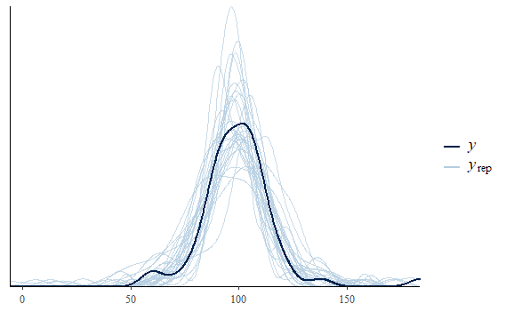

```r
ppc_dens_overlay(y[placebo], y_rep[1:30, placebo])
```

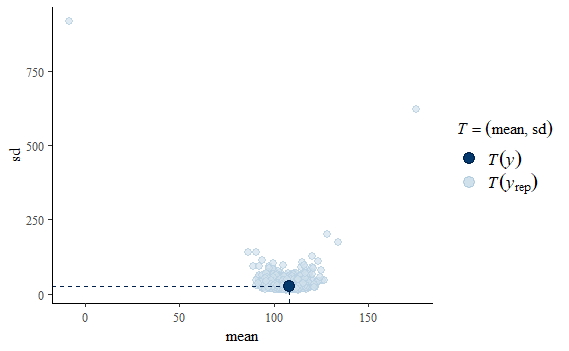

```r
ppc_stat_2d(y[drug], y_rep[ , drug])
```

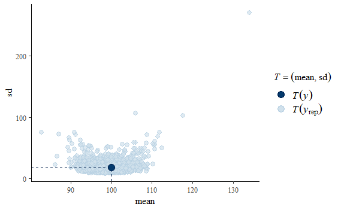

```r
ppc_stat_2d(y[placebo], y_rep[ , placebo])
```

Just for giggles, let’s also check that we can recover our `diff` parameter from the extracted samples:

```r
test_diff <- samples_IQ2$mu[ ,1] - samples_IQ2$mu[ ,2]
head(test_diff)
```

```
[1]  9.172253 10.834551 11.030557  6.774354  3.427358  4.645903
```

```r
head(samples_IQ2$diff)
```

```
[1]  9.172253 10.834551 11.030557  6.774354  3.427358  4.645903
```

So we could also have calculated the difference of means manually, but the benefit of doing it within the Stan code is that we can use all the Stan features to graph `diff` as a parameter rather than having to roll our own code to visualize `diff`.

## ShinyStan

Run the following code from the Console:

```
launch_shinystan(fit_IQ2)
```